# Informe Grupo 23

Mauro Cejas Marcovecchio

## Introducción

Los datos utilizados en este Trabajo Práctico corresponden al ‘Presupuesto de gastos y su ejecución’ del portal de Datos Abiertos del Ministerio de Economía de la República Argentina. Como su nombre lo indica, contiene información acerca de los montos presupuestados iniciales, vigentes, montos comprometidos, ejecutados y pagados de cada uno de los sectores de la Administración Pública Central, agrupados de forma diaria. Cabe aclarar que únicamente incluye datos de los ejercicios 2020 al 2023, que se encuentran expresados en millones de pesos y fue actualizado por última vez el 16 de junio del mismo año.

Por lo pronto, con el objetivo de contar con la versión más actualizada disponible de esta base de datos cada vez que lo querramos así, vamos a armar un script aparte para automatizar la descarga desde la web. Éste será llamado actualizacion_datos.R y podrá ser encontrado en su carpeta correspondiente.

## Exploración de los datos

En primer lugar, vamos a analizar los datos con los que contamos. Para ello, vamos a especificar el separador de decimales que es utilizado en el archivo.

```r
presupuesto23 <- read_csv("datos/credito-diario-2023.csv", locale = locale(decimal_mark = ","))
presupuesto22 <- read_csv("datos/credito-diario-2022.csv", locale = locale(decimal_mark = ","))
presupuesto21 <- read_csv("datos/credito-diario-2021.csv", locale = locale(decimal_mark = ","))
presupuesto20 <- read_csv("datos/credito-diario-2020.csv", locale = locale(decimal_mark = ","))
```

Asimismo, vamos a juntar los datos de los cuatro ejercicios en una sola variable que se llame presupuesto.

```r
presupuesto <- bind_rows(presupuesto20,presupuesto21,presupuesto22,presupuesto23)
```

Posteriormente, vamos a renombrar algunas columnas para que sea más fácil comprender qué datos contienen.

```r
presupuesto <- presupuesto |>
  rename (presupuesto_inicial = credito_presupuestado, presupuesto_vigente = credito_vigente, comprometido = credito_comprometido, ejecutado = credito_devengado, pagado = credito_pagado, dia = impacto_presupuestario_fecha, mes = impacto_presupuestario_mes, anio = impacto_presupuestario_anio )
```

Luego, vamos a descartar aquellas columnas cuyo análisis no nos interesa.

```r
presupuesto <- presupuesto |>
  select(-c(ultima_actualizacion_fecha, codigo_bapin_desc, codigo_bapin_id, prestamo_externo_desc, prestamo_externo_id, ejercicio_presupuestario))
```

Así, podemos calcular la suma del presupuesto total vigente de toda la administración nacional.

```r
presupuesto |>
  group_by(anio) |>
  summarise(presup_vigente_total = sum(presupuesto_vigente, na.rm = TRUE)) |>
  kable(col.names = c("Año","Presupuesto Anual"))
```

| Año | Presupuesto Anual |
| --- | --- |
| 2020 | 7762601 |
| 2021 | 11000407 |
| 2022 | 18126071 |
| 2023 | 29129581 |

Como también podemos discriminar qué presupuesto fue asignado a cada jurisdicción.

```r
presupuesto |>
  group_by(jurisdiccion_desc, anio) |>
  summarise(presup_vigente_minist = sum(presupuesto_vigente, na.rm = TRUE)) |>
  pivot_wider(names_from = anio, values_from = presup_vigente_minist) |>
  kable(col.names = c("Jurisdicción","2020","2021","2022","2023"))
```

| Jurisdicción | 2020 | 2021 | 2022 | 2023 |
| --- | --- | --- | --- | --- |
| Jefatura de Gabinete de Ministros | 30569.723 | 30116.18 | 57865.76 | 130734.85 |
| Ministerio Público | 28195.495 | 49052.20 | 87360.08 | 121810.87 |
| Ministerio de Agricultura, Ganadería y Pesca | 38020.909 | 60163.05 | 127265.91 | NA |
| Ministerio de Ambiente y Desarrollo Sostenible | 6076.919 | 16771.25 | 41396.20 | 55479.97 |
| Ministerio de Ciencia, Tecnología e Innovación | 33393.443 | 61162.77 | 132322.97 | 213067.29 |
| Ministerio de Cultura | 10037.309 | 23104.11 | 34948.37 | 46476.25 |
| Ministerio de Defensa | 213619.277 | 339831.72 | 571806.67 | 829401.56 |
| Ministerio de Desarrollo Productivo | 591683.550 | 139449.14 | 88039.94 | NA |
| Ministerio de Desarrollo Social | 243518.951 | 531071.00 | 999909.36 | 1170219.19 |
| Ministerio de Desarrollo Territorial y Hábitat | 35028.241 | 303820.29 | 253841.70 | 387904.71 |
| Ministerio de Economía | 10246.147 | 1004212.37 | 1436681.57 | 2427918.63 |
| Ministerio de Educación | 278997.735 | 546616.69 | 977115.75 | 1376262.86 |
| Ministerio de Justicia y Derechos Humanos | 28548.232 | 43475.87 | 74282.06 | 96028.43 |
| Ministerio de Obras Públicas | 150834.840 | 351587.81 | 455958.70 | 723525.20 |
| Ministerio de Relaciones Exteriores, Comercio Internacional y Culto | 31059.271 | 45414.54 | 64051.31 | 105857.54 |
| Ministerio de Salud | 167782.381 | 353824.85 | 369519.03 | 481540.26 |
| Ministerio de Seguridad | 244172.604 | 391119.61 | 767562.53 | 1088646.20 |
| Ministerio de Trabajo, Empleo y Seguridad Social | 3422098.282 | 4251605.21 | 7301107.05 | 12103987.33 |
| Ministerio de Transporte | 101455.868 | 158878.55 | 253208.00 | 368088.30 |
| Ministerio de Turismo y Deportes | 13425.878 | 46093.57 | 46752.48 | 71140.11 |
| Ministerio de las Mujeres, Géneros y Diversidad | 1064.336 | 17582.87 | 43532.73 | 54683.36 |
| Ministerio del Interior | 92582.440 | 92172.48 | 88380.24 | 234922.62 |
| Obligaciones a Cargo del Tesoro | 688403.254 | 860211.61 | 1323169.69 | 2667018.97 |
| Poder Judicial de la Nación | 76305.307 | 129100.64 | 228517.65 | 342959.37 |
| Poder Legislativo Nacional | 39503.038 | 59137.36 | 103226.77 | 133718.78 |
| Presidencia de la Nación | 215441.860 | 319872.32 | 581504.72 | 970630.52 |
| Servicio de la Deuda Pública | 970535.367 | 774959.00 | 1616744.02 | 2927557.72 |

Podemos descubrir las tres jurisdicciones que tuvieron mayor cantidad de presupuesto asignado.

```r
presupuesto |>
  group_by(jurisdiccion_desc) |>
  summarise(presup_vigente_minist = sum(presupuesto_vigente, na.rm = TRUE)) |>
  slice_max(presup_vigente_minist, n = 3) |>
  kable(col.names = c("Jurisdicción","Presupuesto Asignado"))
```

| Jurisdicción | Presupuesto Asignado |
| --- | --- |
| Ministerio de Trabajo, Empleo y Seguridad Social | 27078798 |
| Servicio de la Deuda Pública | 6289796 |
| Obligaciones a Cargo del Tesoro | 5538804 |

Y aquellas que tienen menor presupuesto asignado

```r
presupuesto |>
  group_by(jurisdiccion_desc) |>
  summarise(presup_vigente_minist = sum(presupuesto_vigente, na.rm = TRUE)) |>
  slice_min(presup_vigente_minist, n = 3) |>
  kable(col.names = c("Jurisdicción","Presupuesto Asignado"))
```

| Jurisdicción | Presupuesto Asignado |
| --- | --- |
| Ministerio de Cultura | 114566.0 |
| Ministerio de las Mujeres, Géneros y Diversidad | 116863.3 |
| Ministerio de Ambiente y Desarrollo Sostenible | 119724.3 |

## Hipótesis

A partir de los datos del Presupuesto de gastos y su ejecución podríamos plantearnos una cantidad ilimitada de preguntas. Algunas de ellas pueden ser cómo fue la evolución de la ejecución del presupuesto a lo largo de los años, en su conjunto y en cada uno de los ministerios. Otra puede estar relacionada a cómo se vió modificado el poder de compra del presupuesto en estos años, tomando en cuenta las variaciones del tipo de cambio que tuvo nuestro país. En lo que sigue del Trabajo Práctico, intentaremos responderlas.

## Desarrollo

En primer lugar, entonces podemos graficar la evolución de la ejecución del presupuesto a lo largo de estos años a valor de pesos corrientes. Para ello, podemos utilizar ggplot2 y expresarlo de billones de pesos (para poder verlo de forma más clara).

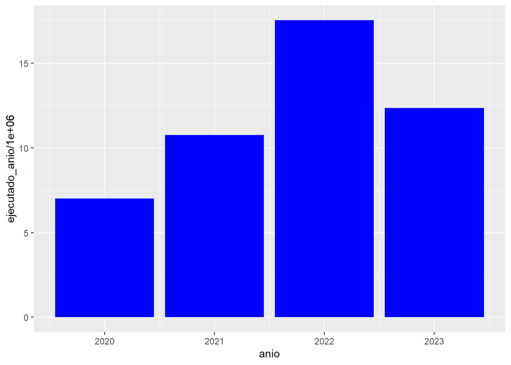

```r
presupuesto |>
  group_by(anio) |>
  summarise(ejecutado_anio = sum(ejecutado, na.rm = TRUE)) |>
  ggplot(aes(anio, ejecutado_anio/1000000)) +
    geom_col(fill = "blue")
```

```r
presupuesto |>
  group_by(anio) |>
  summarise(ejecutado_anio = sum(ejecutado, na.rm = TRUE)) |>
  kable(col.names = c("Año","Ejecución"))
```

| Año | Ejecución |
| --- | --- |
| 2020 | 7001429 |
| 2021 | 10763164 |
| 2022 | 17529194 |
| 2023 | 12339570 |

De la misma manera, podemos graficar la ejecución mensual de cada año.

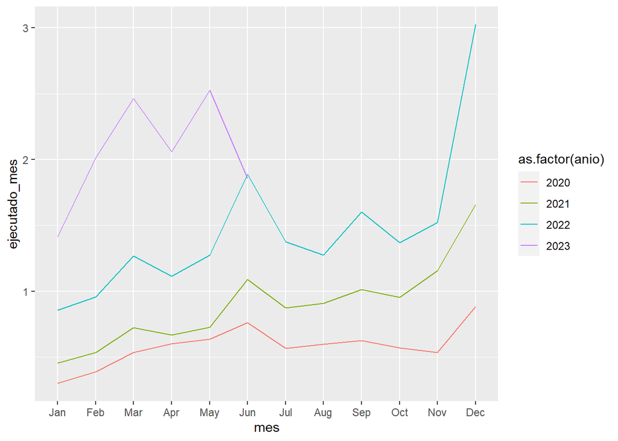

```r
nombres_meses <- month.abb

presupuesto |>
  group_by(mes, anio) |>
  summarise(ejecutado_mes = sum(ejecutado/1000000, na.rm = TRUE)) |>
  ggplot(aes(mes, ejecutado_mes)) +
    geom_line(aes(color = as.factor(anio))) +
      scale_x_discrete(limits = nombres_meses)
```

Es por ello que, en segundo lugar, vamos a intentar expresar el presupuesto ejecutado durante los ejercicios 2020 a 2023 en dólares. Con ese fin, utilizaremos las cotizaciones históricas del dólar oficial minorista obtenidas manualmente desde la página web de Rava Bursátil.

```r
dolaroficial <- read_csv("datos/dolaroficial.csv")
```

Así, vamos a crear una nueva columna en la variable Presupuesto con la cotización diaria que corresponda y su valor de la ejecución en dólares.

```r
presupuesto <- presupuesto |>
  mutate(dia = ymd(dia))
```

```r
presupuestousd <- presupuesto |>
  left_join(
    dolaroficial |> select("ultimo","fecha"),
    by = c ("dia" = "fecha"))
```

```r
presupuestousd <- presupuestousd |>
  rename(cotizacion = ultimo) |>
  mutate(ejecucionusd = ejecutado/cotizacion )
```

Con este nuevo dato, vamos a poder recrear los mismos gráficos y tablas que habíamos hecho anteriormente.

Por un lado, tendremos la ejecución anual en dólares en gráfico de barras.

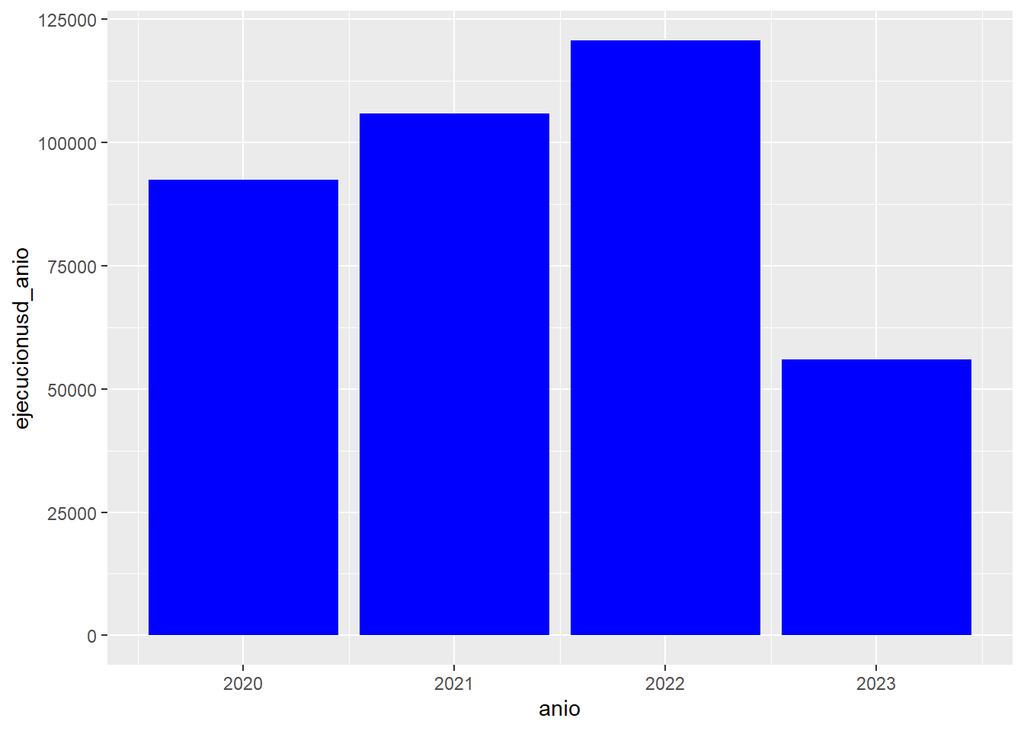

```r
presupuestousd |>
  group_by(anio) |>
  summarise(ejecucionusd_anio = sum(ejecucionusd, na.rm = TRUE)) |>
  ggplot(aes(anio, ejecucionusd_anio)) +
    geom_col(fill = "blue")
```

La ejecución en dólares en formato tabla.

```r
presupuestousd |>
  group_by(anio) |>
  summarise(ejecucionusd_anio = sum(ejecucionusd, na.rm = TRUE)) |>
  kable(col.names = c("Año","Ejecución"))
```

| Año | Ejecución |
| --- | --- |
| 2020 | 92461.63 |
| 2021 | 105957.54 |
| 2022 | 120708.62 |
| 2023 | 55997.40 |

Y finalmente, la ejecución en dólares anual a lo largo del año.

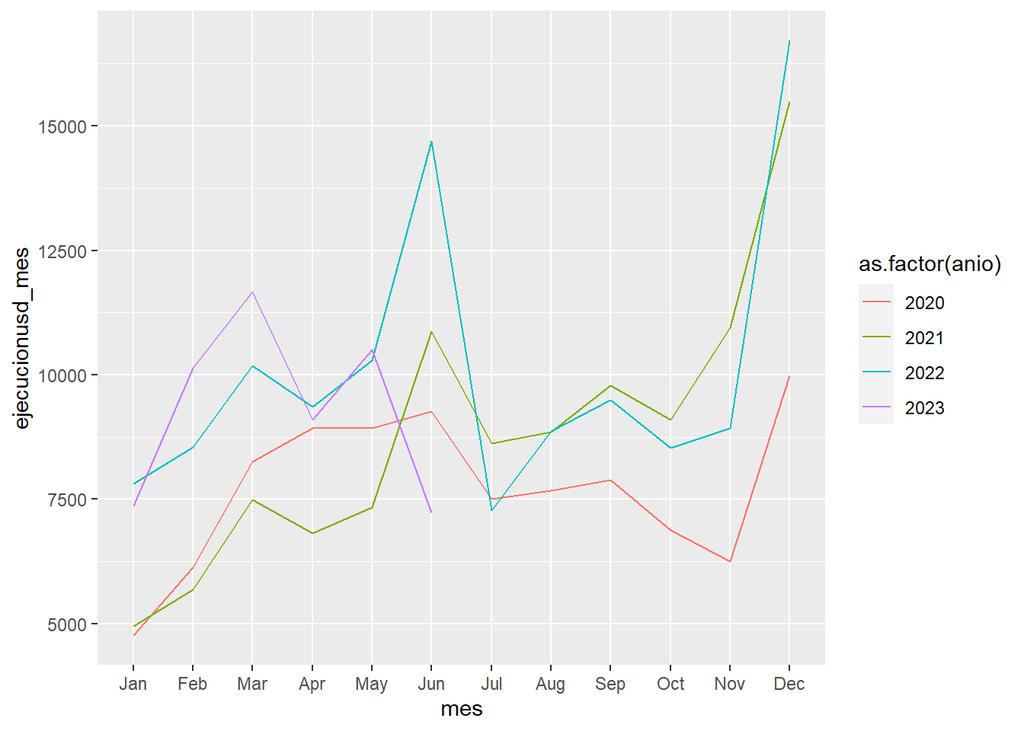

```r
presupuestousd |>
  group_by(mes, anio) |>
  summarise(ejecucionusd_mes = sum(ejecucionusd, na.rm = TRUE)) |>
  ggplot(aes(mes, ejecucionusd_mes)) +
    geom_line(aes(color = as.factor(anio))) +
      scale_x_discrete(limits = nombres_meses)
```

## Conclusiones

1. Si bien empezamos este trabajo con expectativas de resultados que puedan ser clarificadores, al obtener los datos de la ejecución del presupuesto en dólares, no contamos con tantas certezas.
2. Aunque el año de mayor ejecución anual continúa siendo 2022, independientemente si lo considermos utilizando pesos corrientes o dólares, ya no estamos seguros que el 2023 vaya a superarlo. Esto puede inferirse por encontrarnos a mediados del mes de junio de 2023 y la corriente ejecución no haya alcanzado todavía la mitad de su valor.
3. Es clara la tendencia de mayores niveles de ejecución hacia fines de cada año que, al igual que la ejecución presupuestaria de cada Ministerio, puede llegar a ser analizada más profundamente en posteriores trabajos.